# Satellite-based water level

Water level can be measured from satellites using a radar altimeter. When applied to rivers, such data carries information about streamflow. [Hydroweb](http://hydroweb.theia-land.fr/) collects altimetry data from various satellites (Envisat, Jason-2 and Jason-3). Hydroweb's data is freely available but you need to create an account. I downloaded all the data relative to the Amazon river basin. There are actually two types of data: research and operational. I will first take a look at the data altogether.

```python
import os
import numpy as np
import matplotlib.pyplot as plt
from mpl_toolkits.basemap import Basemap
import pandas as pd
from pandas import DataFrame
import rasterio
from tqdm import tqdm
import pickle

%matplotlib inline
```

```python
def get_heights():
    heights = {'research': [], 'operational': []}
    data_path = '../data/amazon/hydroweb/'
    files = os.listdir(data_path)
    for name in tqdm(files):
        with open(data_path + name, 'rt') as f:
            data = f.read().split('\n')
        line = data[0]
        latlon = line[line.find(';lat=') + 1:line.find(';ref=')]
        vs_type = line[line.find(';type=') + 6:line.find(';diff=')]
        i, done = 1, False
        while not done:
            line = data[i]
            if line[0] == '#':
                i += 1
            else:
                done = True
        df = pd.read_csv(data_path + name, sep=';', skiprows=i, header=None, names=['1', 'date', 'time', latlon, '5', '6', '7']).drop(['1', '5', '6', '7'], 1)
        df['datetime'] = pd.to_datetime(df['date'] + df['time'])
        s = df.set_index(['datetime'])[latlon]
        heights[vs_type].append(s)
    return heights
```

```python
heights = get_heights()
```

```python
def plot_in_space(heights, alpha):
    lat0, lat1, lon0, lon1 = -30, 15, -90, -30
    plt.close('all')
    fig = plt.figure()
    ax = fig.add_subplot(111)
    m = Basemap(projection='cyl', resolution='l', area_thresh=10000, llcrnrlat=lat0, urcrnrlat=lat1, llcrnrlon=lon0, urcrnrlon=lon1)
    m.drawcoastlines()
    m.drawcountries()
    lat = [float(s.name[4:s.name.find(';')]) for s in heights]
    lon = [float(s.name[s.name.find(';lon=') + 5:]) for s in heights]
    ax.scatter(lon, lat, color='red', alpha=alpha)
    plt.show()
```

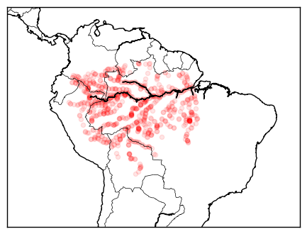

```python
plot_in_space(heights['research'] + heights['operational'], 0.1)
```

Spatially, there is actually quite a lot of data. Let's see what we have temporally by plotting the normalized water levels.

```python
def plot_in_time(heights, alpha):
    plt.close('all')
    plt.figure(figsize=(12, 3))
    for h in heights:
        s = h.values
        s -= np.min(s)
        s /= np.max(s)
        plt.plot(h.index, s, color='blue', alpha=alpha)
    plt.show()
```

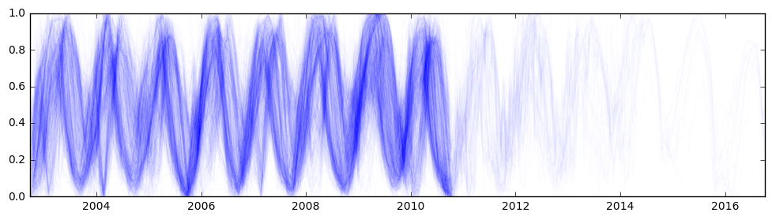

```python
plot_in_time(heights['research'] + heights['operational'], 0.01)
```

As you can see in the figure above, a lot of data lies between 2003 and 2011, and a lot less from 2011 on. The former corresponds to the research data, and the latter to the operational data. Let's look at the sampling period of research data:

```python
def get_sampling_period(heights):
    delta = []
    for h in heights:
        delta.append(np.mean(h.index.values[1:] - h.index.values[:-1]))
    return np.mean(delta).astype('timedelta64[D]')
```

```python
print(get_sampling_period(heights['research']))
```

```
35 days
```

Research data is very poorly sampled temporally, not even one data per month. Now let's look at operational data:

```python
print(get_sampling_period(heights['operational']))
```

```
10 days
```

Operational data is sampled much more frequently, but there are much less virtual stations:

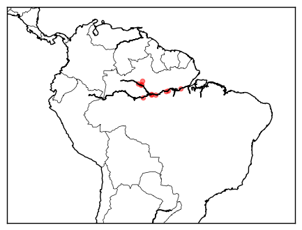

```python
plot_in_space(heights['operational'], 0.5)
```

Research data was acquired by the Envisat satellite, and operational data by the Jason-2/3 satellites. They have different characteristics which can explain the differences in spatial/temporal sampling. But given that the larger the river, the better the quality of the water level measurements, it may not be a good idea to keep the research data, which covers a lot more territory but also much smaller rivers. So let's focus on operational data, whose 11 virtual station water levels are represented here:

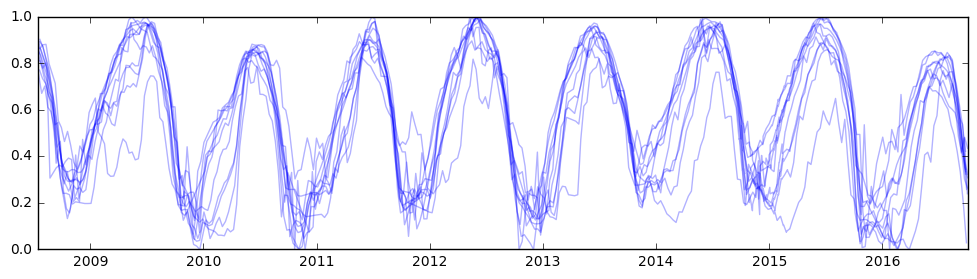

```python
plot_in_time(heights['operational'], 0.3)
```

It is also a good idea to keep a relatively small number of virtual stations, because we will see that the position of the virtual stations as given by Hydroweb don't necessarily match the [HydroSHEDS](http://hydrosheds.cr.usgs.gov/index.php)'s drainage network and flow accumulation data, which we will use for [GROSS](http://davidbrochart.github.io/gross/update/2015/11/26/introducing-gross.html). Some visual adjusting will be required to find the virtual station on the flow accumulation map. To do that, I showed the flow accumulation map centered on each virtual station. The left column corresponds to the original position of the virtual stations, marked as a white dot. We can see that most of the time, it is not located on the river. So I manually applied a correction in order to move the position by a number of x/y pixels. The right column shows the corrected position of the virtual stations. Sometimes it is trivial, because there is only one river around, but when the virtual station is near a confluence, then we need to carefully see where it is supposed to be located. Fortunately, Hydroweb provides a map of the virtual stations, overlaid with satellite imagery. This makes it possible to match with the flow accumulation map.

```python
with rasterio.drivers():
    with rasterio.open('tmp/sa_acc_15s/sa_acc_15s/w001001.adf') as src:
        data, = src.read()
        acc_aff = src.affine
```

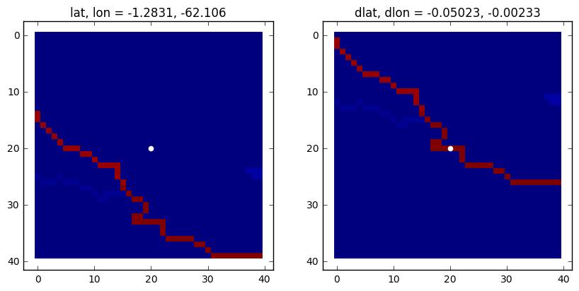

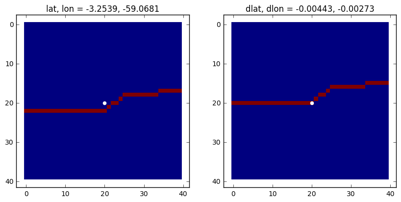

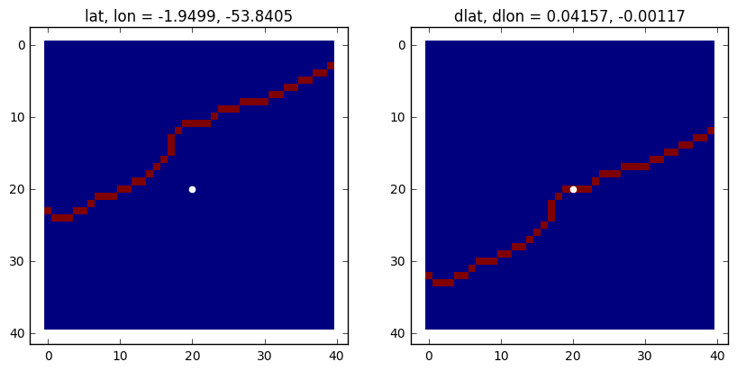

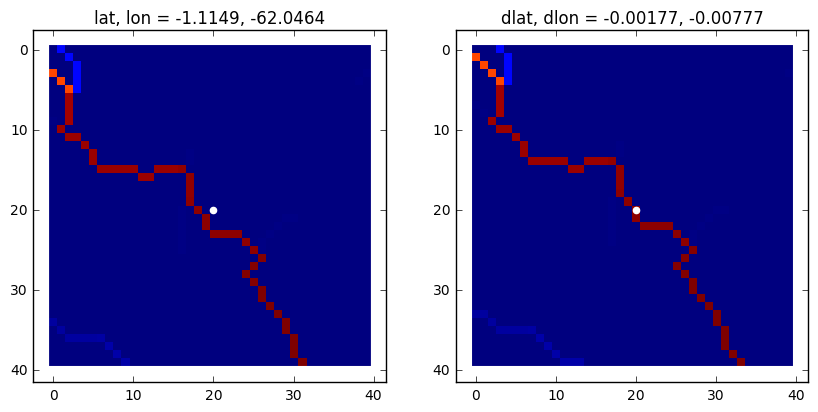

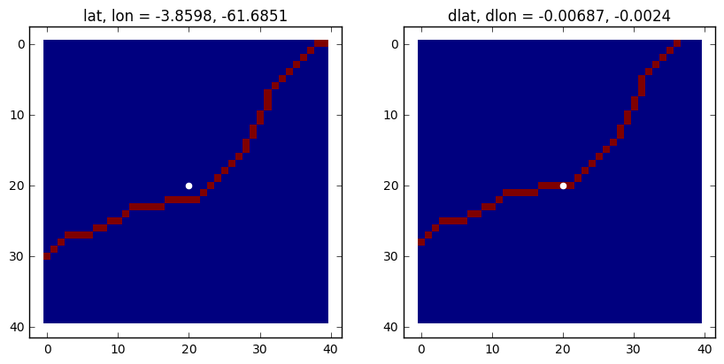

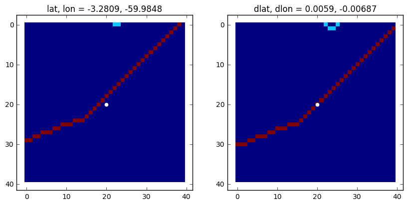

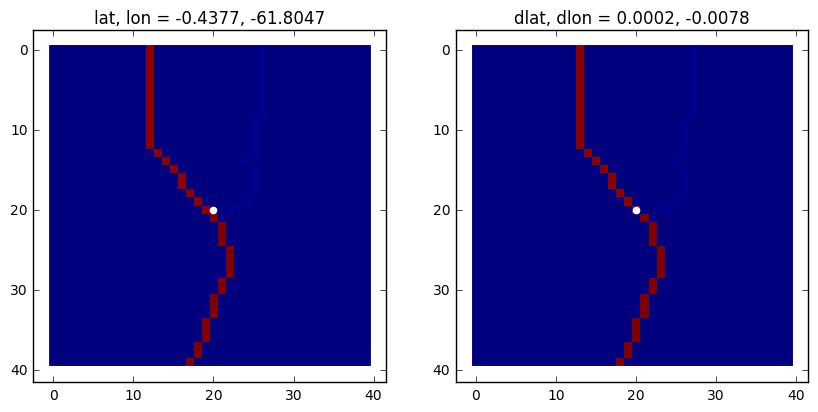

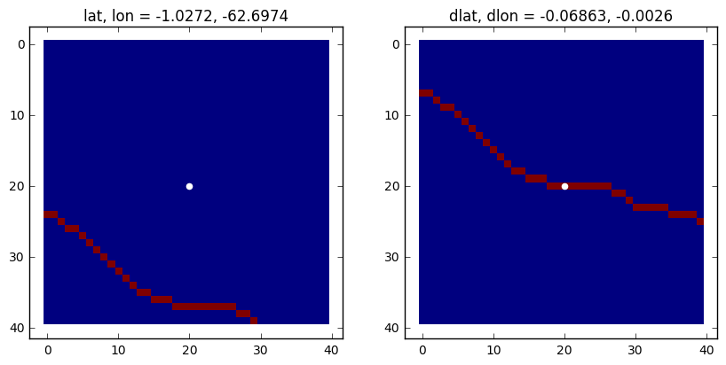

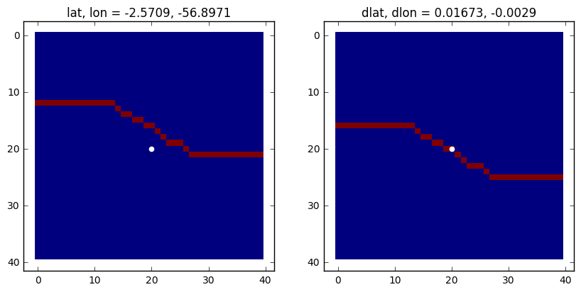

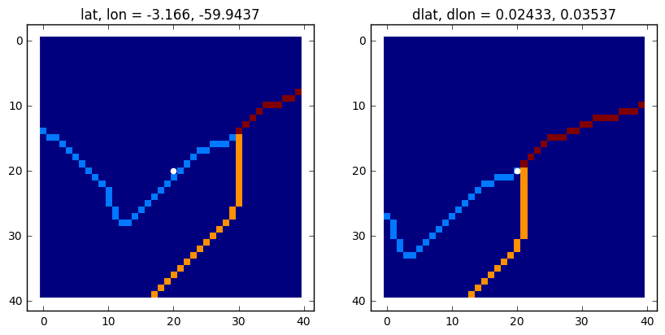

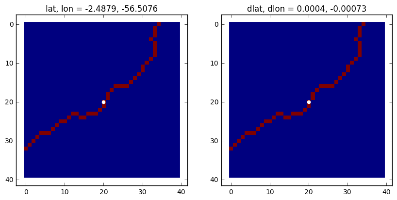

```python
lat = [float(s.name[4:s.name.find(';')]) for s in heights['operational']]
lon = [float(s.name[s.name.find(';lon=') + 5:]) for s in heights['operational']]
correction = [[13, 0], [2, 0], [-9, 0], [1, -1], [2, 0], [-1, -1], [0, -1], [17, 0], [-4, 0], [-5, 9], [0, 0]]
new_latlon = []
for i, lonlat in enumerate(list(zip(lon, lat))):
    x, y = [int(round(j, 5)) for j in ~acc_aff * lonlat]
    plt.close('all')
    f, (ax1, ax2) = plt.subplots(1, 2)
    f.set_size_inches(10, 10)
    d = 20
    ax1.imshow(data[y-d:y+d, x-d:x+d], interpolation='nearest')
    ax1.scatter(d, d, color='white')
    ax1.set_title('lat, lon = ' + str(lonlat[1]) + ', ' + str(lonlat[0]))
    dy, dx = correction[i]
    lonlat2 = acc_aff * [x + dx, y + dy]
    new_latlon.append(lonlat2[::-1])
    ax2.imshow(data[y-d+dy:y+d+dy, x-d+dx:x+d+dx], interpolation='nearest')
    ax2.scatter(d, d, color='white')
    dlat = round(lonlat2[1] - lonlat[1], 5)
    dlon = round(lonlat2[0] - lonlat[0], 5)
    ax2.set_title('dlat, dlon = ' + str(dlat) + ', ' + str(dlon))
    plt.show()
```

Let's check that the flow accumulation at the position of each virtual station is reasonably high.

```python
for latlon in new_latlon:
    x, y = [int(round(i, 5)) for i in ~acc_aff * latlon[::-1]]
    print(data[y, x])
```

```
1819885
13755332
24849260
53104
8506136
10397620
840321
1771412
20724865
3331555
21354315
```

Which is okay. We will use these virtual station positions in the basin partitionning, which will be explained in another notebook.

```python
with open('tmp/vs_latlon.pkl', 'wb') as f:
    pickle.dump(new_latlon, f)
```